# Biostat 203B Homework 4

Due Mar 24 @ 11:59PM

Load database libraries and the tidyverse frontend:

```r
suppressPackageStartupMessages(library(tidyverse))
suppressPackageStartupMessages(library(tidymodels))
suppressPackageStartupMessages(library(lubridate))
suppressPackageStartupMessages(library(dplyr))
suppressPackageStartupMessages(library(gtsummary))
suppressPackageStartupMessages(library(GGally))
suppressPackageStartupMessages(library(kernlab))
suppressPackageStartupMessages(library(ranger))
```

## 1 Predicting 30-day mortality

Using the ICU cohort `icu_cohort.rds` you built in Homework 3, develop at least three analytic approaches for predicting the 30-day mortality of patients admitted to ICU using demographic information (gender, age, marital status, ethnicity), first lab measurements during ICU stay, and first vital measurements during ICU stay. For example, you can use (1) logistic regression with elastic net (lasso + ridge) penalty (e.g., glmnet or keras package), (2) random forest, (3) boosting, and (4) support vector machines, or (5) MLP neural network (keras package).

```r
icu_cohort <- readRDS("../hw3/mimiciv_shiny/icu_cohort.rds") %>%
  select(
    -subject_id,
    -intime,
    -hadm_id,
    -stay_id,
    -last_careunit,
    -outtime,
    -los,
    -admittime,
    -dischtime,
    -deathtime,
    -discharge_location,
    -edregtime,
    -edouttime,
    -hospital_expire_flag,
    -anchor_age,
    -anchor_year,
    -anchor_year_group,
    -dod)
icu_cohort %>% tbl_summary(by = thirty_day_mort)
```

| **Characteristic** | **FALSE**, N = 45,148<sup>1</sup> | **TRUE**, N = 7,917<sup>1</sup> |
| --- | --- | --- |
| first_careunit |  |  |
| Cardiac Vascular Intensive Care Unit (CVICU) | 8,909 (20%) | 539 (6.8%) |
| Coronary Care Unit (CCU) | 5,020 (11%) | 1,078 (14%) |
| Medical Intensive Care Unit (MICU) | 8,133 (18%) | 2,074 (26%) |
| Medical/Surgical Intensive Care Unit (MICU/SICU) | 7,079 (16%) | 1,740 (22%) |
| Neuro Intermediate | 1,264 (2.8%) | 47 (0.6%) |
| Neuro Stepdown | 596 (1.3%) | 30 (0.4%) |
| Neuro Surgical Intensive Care Unit (Neuro SICU) | 1,121 (2.5%) | 259 (3.3%) |
| Surgical Intensive Care Unit (SICU) | 6,970 (15%) | 1,268 (16%) |
| Trauma SICU (TSICU) | 6,056 (13%) | 882 (11%) |
| admission_type |  |  |
| AMBULATORY OBSERVATION | 18 (<0.1%) | 1 (<0.1%) |
| DIRECT EMER. | 1,517 (3.4%) | 321 (4.1%) |
| DIRECT OBSERVATION | 97 (0.2%) | 18 (0.2%) |
| ELECTIVE | 1,868 (4.1%) | 133 (1.7%) |
| EU OBSERVATION | 273 (0.6%) | 33 (0.4%) |
| EW EMER. | 22,226 (49%) | 4,766 (60%) |
| OBSERVATION ADMIT | 5,377 (12%) | 767 (9.7%) |
| SURGICAL SAME DAY ADMISSION | 5,614 (12%) | 260 (3.3%) |
| URGENT | 8,158 (18%) | 1,618 (20%) |
| admission_location |  |  |
| AMBULATORY SURGERY TRANSFER | 35 (<0.1%) | 3 (<0.1%) |
| CLINIC REFERRAL | 359 (0.8%) | 141 (1.8%) |
| EMERGENCY ROOM | 20,724 (46%) | 4,407 (56%) |
| INFORMATION NOT AVAILABLE | 137 (0.3%) | 31 (0.4%) |
| INTERNAL TRANSFER TO OR FROM PSYCH | 11 (<0.1%) | 0 (0%) |
| PACU | 247 (0.5%) | 28 (0.4%) |
| PHYSICIAN REFERRAL | 11,308 (25%) | 973 (12%) |
| PROCEDURE SITE | 736 (1.6%) | 73 (0.9%) |
| TRANSFER FROM HOSPITAL | 10,372 (23%) | 2,023 (26%) |

[output cut: 54 more lines]

<sup>1</sup> n (%); Median (IQR)

```r
# Choose features we're interested in including in the model
cat_features <- c("first_careunit", "admission_type", "insurance","ethnicity",
                  "gender")
num_features <- c("adm_age", "WhiteBloodCells", "Glucose","HeartRate", "RespiratoryRate")
features <- c(cat_features, num_features)
```

```r
icu_tbl <- icu_cohort %>%
  select(features, thirty_day_mort) %>%
  print(width = Inf)
```

```
# A tibble: 53,065 × 11
   first_careunit admission_type              insurance ethnicity
   <chr>          <chr>                       <chr>     <chr>
 1 Neuro Stepdown OBSERVATION ADMIT           Medicare  OTHER
 2 Neuro Stepdown SURGICAL SAME DAY ADMISSION Other     OTHER
 3 Neuro Stepdown OBSERVATION ADMIT           Other     WHITE
 4 Neuro Stepdown OBSERVATION ADMIT           Other     WHITE
 5 Neuro Stepdown OBSERVATION ADMIT           Other     BLACK/AFRICAN AMERICAN
 6 Neuro Stepdown OBSERVATION ADMIT           Other     WHITE
 7 Neuro Stepdown OBSERVATION ADMIT           Other     HISPANIC/LATINO
 8 Neuro Stepdown SURGICAL SAME DAY ADMISSION Other     WHITE
 9 Neuro Stepdown OBSERVATION ADMIT           Other     WHITE
10 Neuro Stepdown URGENT                      Other     WHITE
   gender adm_age WhiteBloodCells Glucose HeartRate RespiratoryRate
   <chr>    <int>           <dbl>   <dbl>     <dbl>           <dbl>
```

[output cut: 23 more lines]

```r
# Many categorical variables have too many minor levels, so combine levels into
# "Other" category by proportion

icu_tbl$first_careunit <- fct_lump_prop(icu_tbl$first_careunit, prop = 0.15,
                                        w = NULL, other_level = "Other")
icu_tbl$admission_type <- fct_lump_prop(icu_tbl$admission_type, prop = 0.10,
                                        w = NULL, other_level = "Other")
icu_tbl$ethnicity <- fct_lump_prop(icu_tbl$ethnicity, prop = 0.04, w = NULL,
                                   other_level = "Other")
icu_tbl$thirty_day_mort <- as.factor(icu_tbl$thirty_day_mort)
tbl_summary(icu_tbl, by = thirty_day_mort)
```

| **Characteristic** | **FALSE**, N = 45,148<sup>1</sup> | **TRUE**, N = 7,917<sup>1</sup> |
| --- | --- | --- |
| first_careunit |  |  |
| Cardiac Vascular Intensive Care Unit (CVICU) | 8,909 (20%) | 539 (6.8%) |
| Medical Intensive Care Unit (MICU) | 8,133 (18%) | 2,074 (26%) |
| Medical/Surgical Intensive Care Unit (MICU/SICU) | 7,079 (16%) | 1,740 (22%) |
| Surgical Intensive Care Unit (SICU) | 6,970 (15%) | 1,268 (16%) |
| Other | 14,057 (31%) | 2,296 (29%) |
| admission_type |  |  |
| EW EMER. | 22,226 (49%) | 4,766 (60%) |
| OBSERVATION ADMIT | 5,377 (12%) | 767 (9.7%) |
| SURGICAL SAME DAY ADMISSION | 5,614 (12%) | 260 (3.3%) |
| URGENT | 8,158 (18%) | 1,618 (20%) |
| Other | 3,773 (8.4%) | 506 (6.4%) |
| insurance |  |  |
| Medicaid | 3,331 (7.4%) | 498 (6.3%) |
| Medicare | 18,593 (41%) | 4,183 (53%) |
| Other | 23,224 (51%) | 3,236 (41%) |
| ethnicity |  |  |
| BLACK/AFRICAN AMERICAN | 4,124 (9.1%) | 743 (9.4%) |
| OTHER | 2,208 (4.9%) | 322 (4.1%) |
| UNKNOWN | 4,548 (10%) | 1,263 (16%) |
| WHITE | 30,699 (68%) | 4,927 (62%) |
| Other | 3,569 (7.9%) | 662 (8.4%) |
| gender |  |  |
| F | 19,698 (44%) | 3,616 (46%) |
| M | 25,450 (56%) | 4,301 (54%) |
| adm_age | 65 (53, 77) | 72 (61, 82) |
| WhiteBloodCells | 10.4 (7.6, 14.1) | 11.7 (7.8, 16.9) |
| Unknown | 1,580 | 558 |
| Glucose | 123 (103, 153) | 134 (105, 179) |
| Unknown | 1,355 | 511 |
| HeartRate | 84 (73, 98) | 90 (77, 107) |
| Unknown | 12 | 3 |
| RespiratoryRate | 18.0 (14.0, 21.0) | 20.0 (16.0, 24.0) |
| Unknown | 52 | 10 |

<sup>1</sup> n (%); Median (IQR)

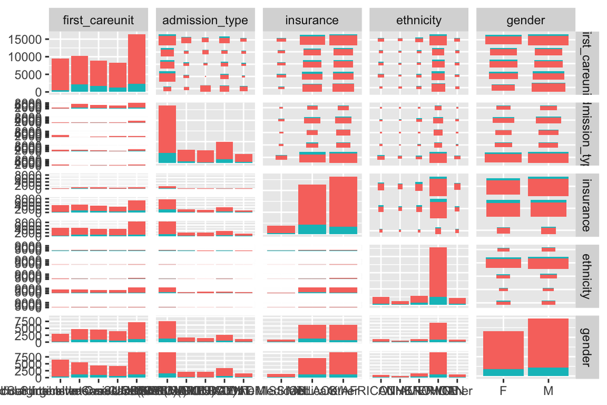

```r
# Visualize data by thirty_day_mort

icu_tbl %>% ggpairs(columns = 1:5, ggplot2::aes(colour = thirty_day_mort))
```

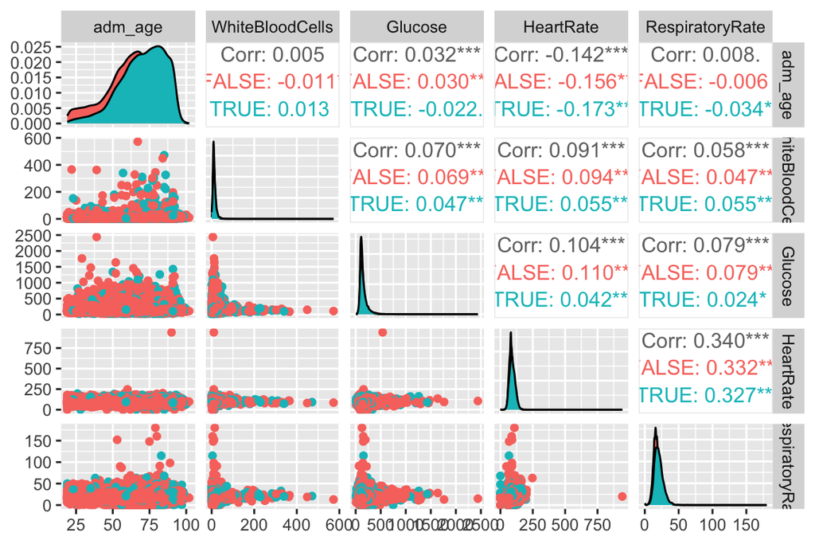

```r
icu_tbl %>% ggpairs(columns = 6:10, ggplot2::aes(colour = thirty_day_mort))
```

1. Partition data into 50% training set and 50% test set. Stratify partitioning according the 30-day mortality status.

```r
set.seed(203)

data_split <- initial_split(
  icu_tbl,
  #stratify by `thirty_day_mort`
  prop = 0.5
)
data_split
```

```
<Training/Testing/Total>
<26532/26533/53065>
```

```r
icu_other <- training(data_split)
dim(icu_other)
```

```
[1] 26532    11
```

```r
icu_test <- testing(data_split)
dim(icu_test)
```

```
[1] 26533    11
```

2. Train and tune the models (random forest, logistic regression with e-net regularization, SVM with radial basis kernel) using the training set.

```r
# Random forest recipe
rf_recipe <- recipe(
  thirty_day_mort ~.,
  data = icu_other
) %>%
  # mode imputation for ethnicity (categorical) for missing/`Unknown` values
  step_impute_mode(ethnicity) %>%
  # mean imputation for `WhiteBloodCells`, `Glucose`, `HeartRate`, and `respiratory rate`
  # which have some but not many missing/unknown values
  step_impute_mean(WhiteBloodCells) %>%
  step_impute_mean(Glucose) %>%
  step_impute_mean(HeartRate) %>%
  step_impute_mean(RespiratoryRate) %>%
  # zero-variance filter on numerical predictors
  step_zv(all_numeric_predictors()) %>%
  step_impute_linear(all_numeric_predictors()) %>%
  prep(training = icu_other, retrain = TRUE)
rf_recipe
```

```
Recipe

Inputs:

      role #variables
   outcome          1
 predictor         10

Training data contained 26532 data points and 1217 incomplete rows.

Operations:

Mode imputation for ethnicity [trained]
Mean imputation for WhiteBloodCells [trained]
Mean imputation for Glucose [trained]
Mean imputation for HeartRate [trained]
Mean imputation for RespiratoryRate [trained]
Zero variance filter removed <none> [trained]
Linear regression imputation for adm_age, WhiteBloodCells, Glucose, HeartRate, ... [trained]
```

```r
# Random forest model
rf_mod <- rand_forest(
  mode = "classification",
  mtry = tune(),
  trees = tune()
) %>%
  set_engine("ranger")
rf_mod
```

```
Random Forest Model Specification (classification)

Main Arguments:
  mtry = tune()
  trees = tune()

Computational engine: ranger
```

```r
# Random forest workflow
rf_wf <- workflow() %>%
  add_recipe(rf_recipe) %>%
  add_model(rf_mod)
rf_wf
```

```
══ Workflow ════════════════════════════════════════════════════════════════════
Preprocessor: Recipe
Model: rand_forest()

── Preprocessor ────────────────────────────────────────────────────────────────
7 Recipe Steps

• step_impute_mode()
• step_impute_mean()
• step_impute_mean()
• step_impute_mean()
• step_impute_mean()
• step_zv()
• step_impute_linear()

── Model ───────────────────────────────────────────────────────────────────────
Random Forest Model Specification (classification)

Main Arguments:
  mtry = tune()
  trees = tune()

Computational engine: ranger
```

```r
# Random forest tuning
param_grid_rf <- grid_regular(
  trees(range = c(100L, 300L)),
  mtry(range = c(1L, 5L)),
  levels = c(3, 5)
)
param_grid_rf
```

```
# A tibble: 15 × 2
   trees  mtry
   <int> <int>
 1   100     1
 2   200     1
 3   300     1
 4   100     2
 5   200     2
 6   300     2
 7   100     3
 8   200     3
 9   300     3
10   100     4
11   200     4
12   300     4
13   100     5
14   200     5
15   300     5
```

```r
# RF Cross Validation
set.seed(203)
folds <- vfold_cv(icu_other, v = 5)
folds
```

```
#  5-fold cross-validation
# A tibble: 5 × 2
  splits               id
  <list>               <chr>
1 <split [21225/5307]> Fold1
2 <split [21225/5307]> Fold2
3 <split [21226/5306]> Fold3
4 <split [21226/5306]> Fold4
5 <split [21226/5306]> Fold5
```

```r
# RF Fit cross validation
system.time({
  rf_fit <- rf_wf %>%
  tune_grid(
    resamples = folds,
    grid = param_grid_rf,
    metrics = metric_set(roc_auc, accuracy)
  )
})
```

```
   user  system elapsed
239.816   8.057 206.773
```

```r
rf_fit
```

```
# Tuning results
# 5-fold cross-validation
# A tibble: 5 × 4
  splits               id    .metrics          .notes
  <list>               <chr> <list>            <list>
1 <split [21225/5307]> Fold1 <tibble [30 × 6]> <tibble [0 × 3]>
2 <split [21225/5307]> Fold2 <tibble [30 × 6]> <tibble [0 × 3]>
3 <split [21226/5306]> Fold3 <tibble [30 × 6]> <tibble [0 × 3]>
4 <split [21226/5306]> Fold4 <tibble [30 × 6]> <tibble [0 × 3]>
5 <split [21226/5306]> Fold5 <tibble [30 × 6]> <tibble [0 × 3]>
```

```
# A tibble: 30 × 8
    mtry trees .metric  .estimator  mean     n std_err .config
   <int> <int> <chr>    <chr>      <dbl> <int>   <dbl> <chr>
 1     1   100 accuracy binary     0.851     5 0.00201 Preprocessor1_Model01
 2     1   100 roc_auc  binary     0.732     5 0.00418 Preprocessor1_Model01
 3     1   200 accuracy binary     0.851     5 0.00199 Preprocessor1_Model02
 4     1   200 roc_auc  binary     0.736     5 0.00354 Preprocessor1_Model02
 5     1   300 accuracy binary     0.851     5 0.00199 Preprocessor1_Model03
 6     1   300 roc_auc  binary     0.736     5 0.00269 Preprocessor1_Model03
 7     2   100 accuracy binary     0.852     5 0.00230 Preprocessor1_Model04
 8     2   100 roc_auc  binary     0.732     5 0.00307 Preprocessor1_Model04
 9     2   200 accuracy binary     0.853     5 0.00211 Preprocessor1_Model05
10     2   200 roc_auc  binary     0.733     5 0.00317 Preprocessor1_Model05
# … with 20 more rows
```

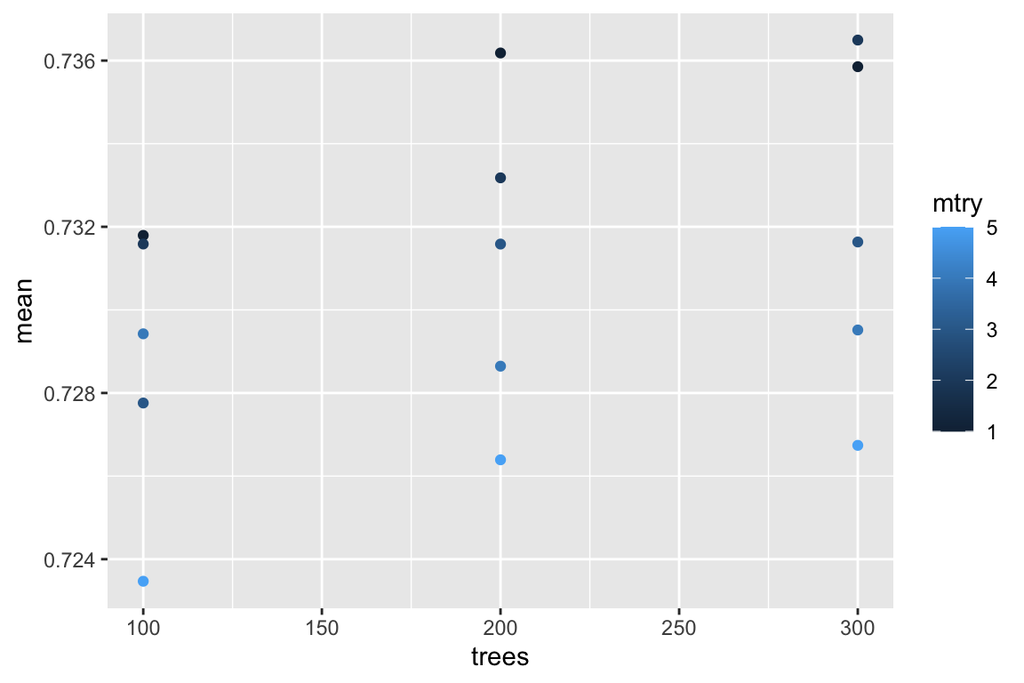

```r
# Visualize random forest cross validation results
rf_fit %>% collect_metrics() %>%
  print(width = Inf) %>%
  filter(.metric == "roc_auc") %>%
  ggplot(mapping = aes(x = trees, y = mean, color = mtry)) +
  geom_point()
```

```r
rf_fit %>% show_best("roc_auc")
```

```
# A tibble: 5 × 8
   mtry trees .metric .estimator  mean     n std_err .config
  <int> <int> <chr>   <chr>      <dbl> <int>   <dbl> <chr>
1     2   300 roc_auc binary     0.736     5 0.00339 Preprocessor1_Model06
2     1   200 roc_auc binary     0.736     5 0.00354 Preprocessor1_Model02
3     1   300 roc_auc binary     0.736     5 0.00269 Preprocessor1_Model03
4     2   200 roc_auc binary     0.733     5 0.00317 Preprocessor1_Model05
5     1   100 roc_auc binary     0.732     5 0.00418 Preprocessor1_Model01
```

```r
best_rf <- rf_fit %>%
  select_best("roc_auc")
best_rf
```

```
# A tibble: 1 × 3
   mtry trees .config
  <int> <int> <chr>
1     2   300 Preprocessor1_Model06
```

```r
# Logistical recipe
logi_recipe <-
  recipe(
    thirty_day_mort ~ .,
    data = icu_other
  ) %>%
  #mode imputation for ethnicity (categorical) for missing/`Unknown` values
  step_impute_mode(ethnicity) %>%
  # mean imputation for `WhiteBloodCells`, `Glucose`, `HeartRate`, and `respiratory rate`
  # which have some but not many missing/unknown values
  step_impute_mean(WhiteBloodCells) %>%
  step_impute_mean(Glucose) %>%
  step_impute_mean(HeartRate) %>%
  step_impute_mean(RespiratoryRate) %>%
  # zero-variance filter on numerical predictors
  step_zv(all_numeric_predictors()) %>%
  step_dummy(all_nominal_predictors()) %>%
  step_normalize(all_numeric_predictors()) %>%
  prep(training = icu_other, retrain = TRUE)
logi_recipe
```

```
Recipe

Inputs:

      role #variables
   outcome          1
 predictor         10

Training data contained 26532 data points and 1217 incomplete rows.

Operations:

Mode imputation for ethnicity [trained]
Mean imputation for WhiteBloodCells [trained]
Mean imputation for Glucose [trained]
Mean imputation for HeartRate [trained]
Mean imputation for RespiratoryRate [trained]
Zero variance filter removed <none> [trained]
Dummy variables from first_careunit, admission_type, insurance, ethnicity, gender [trained]
Centering and scaling for adm_age, WhiteBloodCells, Glucose, HeartRate, R... [trained]
```

```r
# Logistic model
logi_model <-
  logistic_reg(
   penalty = tune(),
   mixture = tune()
  ) %>%
  set_engine("glmnet", standardize = FALSE)
logi_model
```

```
Logistic Regression Model Specification (classification)

Main Arguments:
  penalty = tune()
  mixture = tune()

Engine-Specific Arguments:
  standardize = FALSE

Computational engine: glmnet
```

```r
# Logistic workflow
logi_wf <- workflow() %>%
  add_recipe(logi_recipe) %>%
  add_model(logi_model)
logi_wf
```

```
══ Workflow ════════════════════════════════════════════════════════════════════
Preprocessor: Recipe
Model: logistic_reg()

── Preprocessor ────────────────────────────────────────────────────────────────
8 Recipe Steps

• step_impute_mode()
• step_impute_mean()
• step_impute_mean()
• step_impute_mean()
• step_impute_mean()
• step_zv()
• step_dummy()
• step_normalize()

── Model ───────────────────────────────────────────────────────────────────────
Logistic Regression Model Specification (classification)

Main Arguments:
  penalty = tune()
  mixture = tune()

Engine-Specific Arguments:
  standardize = FALSE

Computational engine: glmnet
```

```r
# Logistic tuning grid
param_grid_l <- grid_regular(
  penalty(range = c(-6,3)),
  mixture(),
  levels = c(100, 5)
)
param_grid_l
```

```
# A tibble: 500 × 2
      penalty mixture
        <dbl>   <dbl>
 1 0.000001         0
 2 0.00000123       0
 3 0.00000152       0
 4 0.00000187       0
 5 0.00000231       0
 6 0.00000285       0
 7 0.00000351       0
 8 0.00000433       0
 9 0.00000534       0
10 0.00000658       0
# … with 490 more rows
```

```r
# Logistic Cross Validation using same folds as RF
system.time({
  logi_fit <- logi_wf %>%
  tune_grid(
    resamples = folds,
    grid = param_grid_l,
    metrics = metric_set(roc_auc, accuracy)
  )
})
```

```
   user  system elapsed
 42.982   3.640  47.129
```

```r
logi_fit
```

```
# Tuning results
# 5-fold cross-validation
# A tibble: 5 × 4
  splits               id    .metrics             .notes
  <list>               <chr> <list>               <list>
1 <split [21225/5307]> Fold1 <tibble [1,000 × 6]> <tibble [0 × 3]>
2 <split [21225/5307]> Fold2 <tibble [1,000 × 6]> <tibble [0 × 3]>
3 <split [21226/5306]> Fold3 <tibble [1,000 × 6]> <tibble [0 × 3]>
4 <split [21226/5306]> Fold4 <tibble [1,000 × 6]> <tibble [0 × 3]>
5 <split [21226/5306]> Fold5 <tibble [1,000 × 6]> <tibble [0 × 3]>
```

```
# A tibble: 1,000 × 8
      penalty mixture .metric  .estimator  mean     n std_err
        <dbl>   <dbl> <chr>    <chr>      <dbl> <int>   <dbl>
 1 0.000001         0 accuracy binary     0.850     5 0.00224
 2 0.000001         0 roc_auc  binary     0.723     5 0.00116
 3 0.00000123       0 accuracy binary     0.850     5 0.00224
 4 0.00000123       0 roc_auc  binary     0.723     5 0.00116
 5 0.00000152       0 accuracy binary     0.850     5 0.00224
 6 0.00000152       0 roc_auc  binary     0.723     5 0.00116
 7 0.00000187       0 accuracy binary     0.850     5 0.00224
 8 0.00000187       0 roc_auc  binary     0.723     5 0.00116
 9 0.00000231       0 accuracy binary     0.850     5 0.00224
10 0.00000231       0 roc_auc  binary     0.723     5 0.00116
   .config
   <chr>
 1 Preprocessor1_Model001
 2 Preprocessor1_Model001
 3 Preprocessor1_Model002
 4 Preprocessor1_Model002
 5 Preprocessor1_Model003
 6 Preprocessor1_Model003
 7 Preprocessor1_Model004
 8 Preprocessor1_Model004
 9 Preprocessor1_Model005
10 Preprocessor1_Model005
# … with 990 more rows
```

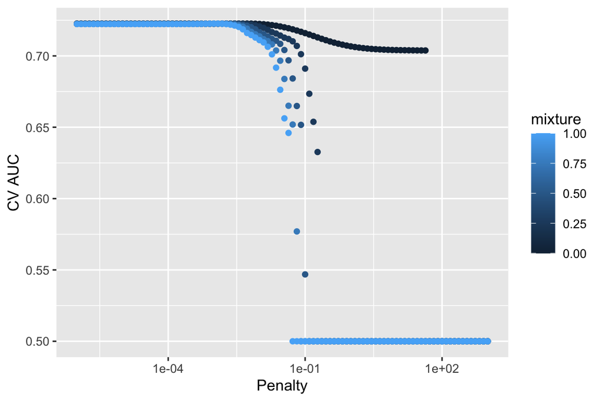

```r
# Visualize logistic regression results
logi_fit %>%
  collect_metrics() %>%
  print(width = Inf) %>%
  filter(.metric == "roc_auc") %>%
  ggplot(mapping = aes(x = penalty, y = mean, color = mixture)) +
  geom_point() +
  labs(x = "Penalty", y = "CV AUC") +
  scale_x_log10()
```

```r
# Top 5 Logistic Models
logi_fit %>%
  show_best("roc_auc")
```

```
# A tibble: 5 × 8
     penalty mixture .metric .estimator  mean     n std_err .config
       <dbl>   <dbl> <chr>   <chr>      <dbl> <int>   <dbl> <chr>
1 0.00534          0 roc_auc binary     0.723     5 0.00115 Preprocessor1_Model…
2 0.000001         0 roc_auc binary     0.723     5 0.00116 Preprocessor1_Model…
3 0.00000123       0 roc_auc binary     0.723     5 0.00116 Preprocessor1_Model…
4 0.00000152       0 roc_auc binary     0.723     5 0.00116 Preprocessor1_Model…
5 0.00000187       0 roc_auc binary     0.723     5 0.00116 Preprocessor1_Model…
```

```r
# Select the best
best_logi <- logi_fit %>%
  select_best("roc_auc")
best_logi
```

```
# A tibble: 1 × 3
  penalty mixture .config
    <dbl>   <dbl> <chr>
1 0.00534       0 Preprocessor1_Model042
```

```r
# SVM with RBF kernel recipe
svm_recipe <- recipe(
  thirty_day_mort ~ .,
  data = icu_other
) %>%
  #mode imputation for ethnicity (categorical) for missing/`Unknown` values
  step_impute_mode(ethnicity) %>%
  # mean imputation for `WhiteBloodCells`, `Glucose`, `HeartRate`, and `respiratory rate`
  # which have some but not many missing/unknown values
  step_impute_mean(WhiteBloodCells) %>%
  step_impute_mean(Glucose) %>%
  step_impute_mean(HeartRate) %>%
  step_impute_mean(RespiratoryRate) %>%
  # zero-variance filter on numerical predictors
  step_zv(all_numeric_predictors()) %>%
  step_dummy(all_nominal_predictors()) %>%
  step_normalize(all_numeric_predictors()) %>%
  prep(training = icu_other, retrain = TRUE)
svm_recipe
```

```
Recipe

Inputs:

      role #variables
   outcome          1
 predictor         10

Training data contained 26532 data points and 1217 incomplete rows.

Operations:

Mode imputation for ethnicity [trained]
Mean imputation for WhiteBloodCells [trained]
Mean imputation for Glucose [trained]
Mean imputation for HeartRate [trained]
Mean imputation for RespiratoryRate [trained]
Zero variance filter removed <none> [trained]
Dummy variables from first_careunit, admission_type, insurance, ethnicity, gender [trained]
Centering and scaling for adm_age, WhiteBloodCells, Glucose, HeartRate, R... [trained]
```

```r
# SVM model
svm_model <- svm_rbf(
  mode = "classification",
  cost = tune(),
  rbf_sigma = tune()
) %>% set_engine("kernlab")
svm_model
```

```
Radial Basis Function Support Vector Machine Model Specification (classification)

Main Arguments:
  cost = tune()
  rbf_sigma = tune()

Computational engine: kernlab
```

```r
# SVM workflow

svm_wf <- workflow() %>%
  add_recipe(svm_recipe) %>%
  add_model(svm_model)
svm_wf
```

```
══ Workflow ════════════════════════════════════════════════════════════════════
Preprocessor: Recipe
Model: svm_rbf()

── Preprocessor ────────────────────────────────────────────────────────────────
8 Recipe Steps

• step_impute_mode()
• step_impute_mean()
• step_impute_mean()
• step_impute_mean()
• step_impute_mean()
• step_zv()
• step_dummy()
• step_normalize()

── Model ───────────────────────────────────────────────────────────────────────
Radial Basis Function Support Vector Machine Model Specification (classification)

Main Arguments:
  cost = tune()
  rbf_sigma = tune()

Computational engine: kernlab
```

```r
# SVM tuning Grid

param_grid_svm <- grid_regular(
  cost(range = c(-8, 5)),
  rbf_sigma(range = c(-5, -3)),
  levels = c(14, 5)
)
param_grid_svm
```

```
# A tibble: 70 × 2
      cost rbf_sigma
     <dbl>     <dbl>
 1 0.00391   0.00001
 2 0.00781   0.00001
 3 0.0156    0.00001
 4 0.0312    0.00001
 5 0.0625    0.00001
 6 0.125     0.00001
 7 0.25      0.00001
 8 0.5       0.00001
 9 1         0.00001
10 2         0.00001
# … with 60 more rows
```

```r
# SVM Cross Validation
system.time({
  svm_fit <- svm_wf %>%
  tune_grid(
    resamples = folds,
    metrics = metric_set(roc_auc, accuracy)
  )
})
```

```
    user   system  elapsed
1895.196   99.649 2046.070
```

```r
svm_fit
```

```
# Tuning results
# 5-fold cross-validation
# A tibble: 5 × 4
  splits               id    .metrics          .notes
  <list>               <chr> <list>            <list>
1 <split [21225/5307]> Fold1 <tibble [20 × 6]> <tibble [0 × 3]>
2 <split [21225/5307]> Fold2 <tibble [20 × 6]> <tibble [0 × 3]>
3 <split [21226/5306]> Fold3 <tibble [20 × 6]> <tibble [0 × 3]>
4 <split [21226/5306]> Fold4 <tibble [18 × 6]> <tibble [1 × 3]>
5 <split [21226/5306]> Fold5 <tibble [18 × 6]> <tibble [1 × 3]>

There were issues with some computations:

  - Error(s) x2: Error in prob.model(object)[[p]]$A: $ operator is invalid for ato...

Run `show_notes(.Last.tune.result)` for more information.
```

```
# A tibble: 20 × 8
       cost rbf_sigma .metric  .estimator  mean     n std_err
      <dbl>     <dbl> <chr>    <chr>      <dbl> <int>   <dbl>
 1  0.00429  2.14e- 8 accuracy binary     0.851     5 0.00199
 2  0.00429  2.14e- 8 roc_auc  binary     0.685     5 0.00397
 3  0.311    2.22e- 2 accuracy binary     0.851     5 0.00199
 4  0.311    2.22e- 2 roc_auc  binary     0.619     5 0.00762
 5  0.0605   2.87e- 5 accuracy binary     0.851     5 0.00199
 6  0.0605   2.87e- 5 roc_auc  binary     0.636     5 0.00470
 7  0.0131   3.68e- 9 accuracy binary     0.851     5 0.00199
 8  0.0131   3.68e- 9 roc_auc  binary     0.673     5 0.00603
 9  0.00233  3.43e- 3 accuracy binary     0.851     5 0.00199
10  0.00233  3.43e- 3 roc_auc  binary     0.519     5 0.00984
11  2.83     1.00e- 6 accuracy binary     0.851     5 0.00199
12  2.83     1.00e- 6 roc_auc  binary     0.624     5 0.0127
```

[output cut: 30 more lines]

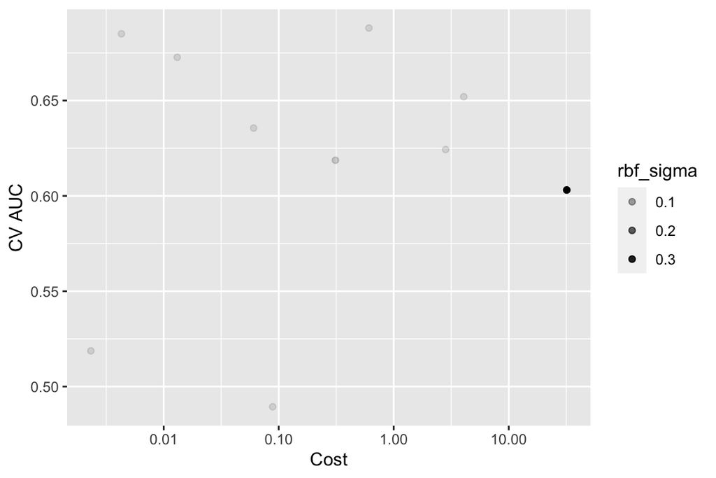

```r
# Visualize SVM CV Results
svm_fit %>%
  collect_metrics() %>%
  print(width = Inf) %>%
  filter(.metric == "roc_auc") %>%
  ggplot(mapping = aes(x = cost, y = mean, alpha = rbf_sigma)) +
  geom_point() +
  labs(x = "Cost", y = "CV AUC") + scale_x_log10()
```

```r
# Show top 5 SVM Models
svm_fit %>%
  show_best("roc_auc")
```

```
# A tibble: 5 × 8
     cost rbf_sigma .metric .estimator  mean     n std_err .config
    <dbl>     <dbl> <chr>   <chr>      <dbl> <int>   <dbl> <chr>
1 0.609    1.90e- 7 roc_auc binary     0.688     5 0.00447 Preprocessor1_Model07
2 0.00429  2.14e- 8 roc_auc binary     0.685     5 0.00397 Preprocessor1_Model01
3 0.0131   3.68e- 9 roc_auc binary     0.673     5 0.00603 Preprocessor1_Model04
4 4.06     1.07e-10 roc_auc binary     0.652     5 0.00906 Preprocessor1_Model09
5 0.0605   2.87e- 5 roc_auc binary     0.636     5 0.00470 Preprocessor1_Model03
```

```r
# Select best SVM model
best_svm <- svm_fit %>%
  select_best("roc_auc")
best_svm
```

```
# A tibble: 1 × 3
   cost   rbf_sigma .config
  <dbl>       <dbl> <chr>
1 0.609 0.000000190 Preprocessor1_Model07
```

3. Compare model classification performance on the test set. Report both the area under ROC curve and accuracy for each model.

```r
#Final RF workflow
final_wf <- rf_wf %>%
  finalize_workflow(best_rf)
final_wf
```

```
══ Workflow ════════════════════════════════════════════════════════════════════
Preprocessor: Recipe
Model: rand_forest()

── Preprocessor ────────────────────────────────────────────────────────────────
7 Recipe Steps

• step_impute_mode()
• step_impute_mean()
• step_impute_mean()
• step_impute_mean()
• step_impute_mean()
• step_zv()
• step_impute_linear()

── Model ───────────────────────────────────────────────────────────────────────
Random Forest Model Specification (classification)

Main Arguments:
  mtry = 2
  trees = 300

Computational engine: ranger
```

```r
final_fit_rf <- final_wf %>%
  last_fit(data_split)
final_fit_rf
```

```
# Resampling results
# Manual resampling
# A tibble: 1 × 6
  splits                id               .metrics .notes   .predict…¹ .workflow
  <list>                <chr>            <list>   <list>   <list>     <list>
1 <split [26532/26533]> train/test split <tibble> <tibble> <tibble>   <workflow>
# … with abbreviated variable name ¹.predictions
```

```r
final_fit_rf %>% collect_metrics()
```

```
# A tibble: 2 × 4
  .metric  .estimator .estimate .config
  <chr>    <chr>          <dbl> <chr>
1 accuracy binary         0.852 Preprocessor1_Model1
2 roc_auc  binary         0.734 Preprocessor1_Model1
```

```r
#Final Logistic Workflow
final_wf_l <- logi_wf %>%
  finalize_workflow(best_logi)
final_wf_l
```

```
══ Workflow ════════════════════════════════════════════════════════════════════
Preprocessor: Recipe
Model: logistic_reg()

── Preprocessor ────────────────────────────────────────────────────────────────
8 Recipe Steps

• step_impute_mode()
• step_impute_mean()
• step_impute_mean()
• step_impute_mean()
• step_impute_mean()
• step_zv()
• step_dummy()
• step_normalize()

── Model ───────────────────────────────────────────────────────────────────────
Logistic Regression Model Specification (classification)

Main Arguments:
  penalty = 0.00533669923120631
  mixture = 0

Engine-Specific Arguments:
  standardize = FALSE

Computational engine: glmnet
```

```r
#Fit the whole training set, then predict the test cases
final_fit_l <- final_wf_l %>%
  last_fit(data_split)
final_fit_l
```

```
# Resampling results
# Manual resampling
# A tibble: 1 × 6
  splits                id               .metrics .notes   .predict…¹ .workflow
  <list>                <chr>            <list>   <list>   <list>     <list>
1 <split [26532/26533]> train/test split <tibble> <tibble> <tibble>   <workflow>
# … with abbreviated variable name ¹.predictions
```

```r
#Test metrics
final_fit_l %>% collect_metrics()
```

```
# A tibble: 2 × 4
  .metric  .estimator .estimate .config
  <chr>    <chr>          <dbl> <chr>
1 accuracy binary         0.849 Preprocessor1_Model1
2 roc_auc  binary         0.716 Preprocessor1_Model1
```

```r
#Final SVM Workflow
final_wf_svm <- svm_wf %>%
  finalize_workflow(best_svm)
final_wf_svm
```

```
══ Workflow ════════════════════════════════════════════════════════════════════
Preprocessor: Recipe
Model: svm_rbf()

── Preprocessor ────────────────────────────────────────────────────────────────
8 Recipe Steps

• step_impute_mode()
• step_impute_mean()
• step_impute_mean()
• step_impute_mean()
• step_impute_mean()
• step_zv()
• step_dummy()
• step_normalize()

── Model ───────────────────────────────────────────────────────────────────────
Radial Basis Function Support Vector Machine Model Specification (classification)

Main Arguments:
  cost = 0.60854368267245
  rbf_sigma = 1.89643624061154e-07

Computational engine: kernlab
```

```r
#Fit the whole training set with SVM, then predict
final_fit_svm <- final_wf_svm %>%
  last_fit(data_split)
final_fit_svm
```

```
# Resampling results
# Manual resampling
# A tibble: 1 × 6
  splits                id               .metrics .notes   .predict…¹ .workflow
  <list>                <chr>            <list>   <list>   <list>     <list>
1 <split [26532/26533]> train/test split <tibble> <tibble> <tibble>   <workflow>
# … with abbreviated variable name ¹.predictions
```

```r
#Test Metrics
final_fit_svm %>%
  collect_metrics()
```

```
# A tibble: 2 × 4
  .metric  .estimator .estimate .config
  <chr>    <chr>          <dbl> <chr>
1 accuracy binary         0.850 Preprocessor1_Model1
2 roc_auc  binary         0.677 Preprocessor1_Model1
```